# Predição Eleições 2014

Emanoel Barros

27 de fevereiro de 2018

Carregando bibliotecas:

```r
library(caret)
library(dplyr)
```

Carregando dados com todas as variáveis:

```r
dados_eleicoes <- read.csv("train.csv", encoding = "UTF-8")
```

**1. Há desbalanceamento das classes (isto é, uma classe tem muito mais instâncias que outra)? Em que proporção? Quais efeitos colaterais o desbalanceamento de classes pode causar no classificador?**

Ao visualizar a variável **situacao_final**, percebemos que há um desbalanceamento entre **eleitos** e **não eleitos**:

```r
dados_eleicoes %>% count(situacao_final)
```

```
## # A tibble: 2 x 2
##   situacao_final     n
##           <fctr> <int>
## 1         eleito   416
## 2     nao_eleito  3719
```

Para uma melhor visualização desse desbalanceamento, plotaremos um gráfico:

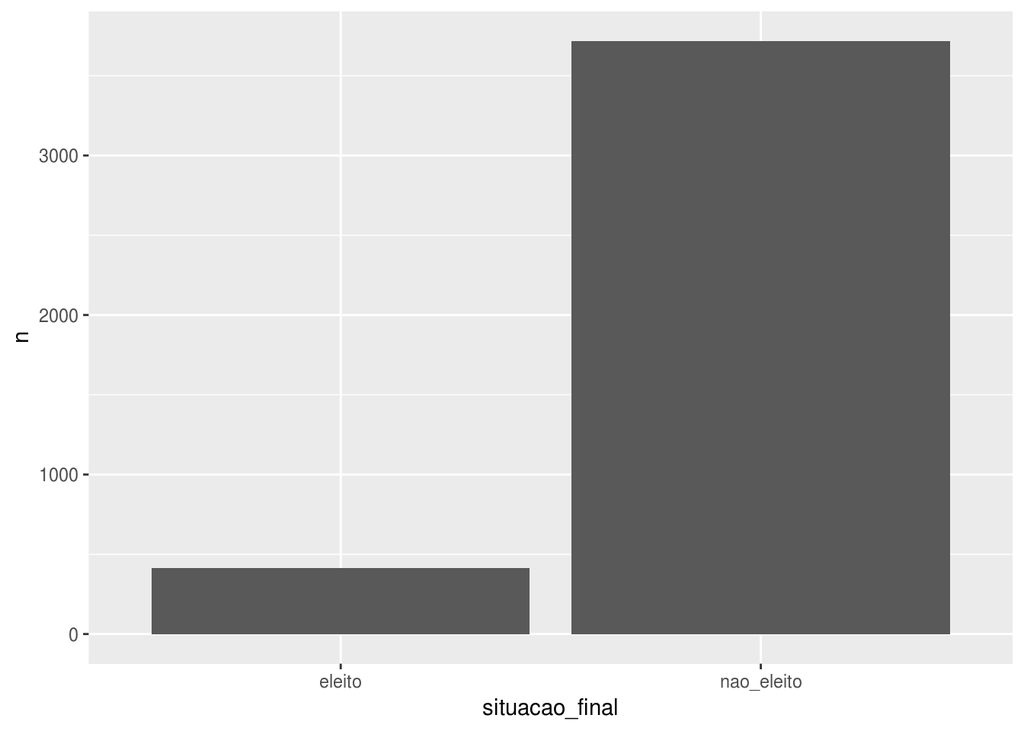

```r
diff_situacao <- dados_eleicoes %>% count(situacao_final)
ggplot(diff_situacao, aes(x = situacao_final, y = n), options(scipen = 5)) +
  geom_bar(stat = "identity")
```

Os dados dispostos dessa forma dificulta o processo de treinamento do modelo, visto que há um viés para um dos valores da variável.

**2. Treine: um modelo de regressão logística, uma árvore de decisão e um modelo de adaboost. Tune esses modelos usando validação cruzada e controle overfitting se necessário, considerando as particularidades de cada modelo.**

Para isso, é necessário separar o dataset em dois: treino e teste. Aqui será dividido em 70% e 30%, respectivamente.

Uma partição é criada contendo os índices de 70% dos dados, que é atribuído ao dataset de treino. Da mesma forma, os outros 30% são atribuídos ao dataset de teste:

```r
particao <- createDataPartition(y = dados_eleicoes$situacao_final, p = 0.70, list = FALSE)

dados_treino <- dados_eleicoes[ particao, ]
dados_teste <- dados_eleicoes[ -particao, ]
```

```r
control <- trainControl(method = "repeatedcv",
                        number = 10,
                        repeats = 10,
                        verboseIter = FALSE,
                        sampling = "down")

formula <- as.formula(situacao_final ~ total_despesa + descricao_cor_raca + estado_civil + grau)
```